# Prediction Project for the Coursera Machine Learning Class

wporter

July 22, 2014

## Background

Using devices such as Jawbone Up, Nike FuelBand, and Fitbit it is now possible to collect a large amount of data about personal activity relatively inexpensively. These type of devices are part of the quantified self movement – a group of enthusiasts who take measurements about themselves regularly to improve their health, to find patterns in their behavior, or because they are tech geeks. One thing that people regularly do is quantify how much of a particular activity they do, but they rarely quantify how well they do it. In this project we are using data from accelerometers on the belt, forearm, arm, and dumbell of 6 participants. They were asked to perform barbell lifts correctly and incorrectly in 5 different ways. More information is available from the website here: http://groupware.les.inf.puc-rio.br/har (see the section on the Weight Lifting Exercise Dataset).

## Project Overview

The goal of this project is to predict the manner in which they did the exercise based on the movement measurements. The prediction is the “classe” variable in the training set and any of the other variables can be used as predictors. The following report describes how the model was built, how it was cross validated, what the expected out of sample error is, and why these methods were used. This model is then used to predict 20 different test cases to answer the Project Assignment Submission questions.

```r
options(warn=-1)
library(caret)
library(randomForest)
library(Hmisc)
set.seed(6628)
```

Reading Files from the working directory.

```r
setwd("~/Documents/Coursera/MachineLearning")
# Training data
trainDf <- read.csv("pml-training.csv", na.strings=c("NA", ""))
dim(trainDf)
```

```
## [1] 19622   160
```

```r
describe(trainDf$classe)
```

```
## trainDf$classe
##       n missing  unique
##   19622       0       5
##
##              A    B    C    D    E
## Frequency 5580 3797 3422 3216 3607
## %           28   19   17   16   18
```

```r
# Testing data
testDf <- read.csv("pml-testing.csv", na.strings=c("NA", ""))
dim(testDf)
```

```
## [1]  20 160
```

Tidy up the data frame by removing the incomplete data columns and the columns that aren’t needed as predictors.

```r
#Find columns with mostly NAs
naColumns = sapply(trainDf, function(x) {sum(is.na(x))})
table(naColumns)
```

```
## naColumns
##     0 19216
##    60   100
```

```r
#Remove columns that are populated with NAs
cleanDf <- trainDf[ , which (naColumns==0)]
#Remove columns that can't be used as predictors
tidyTrainDf <- cleanDf[, -c(1:7)]
```

Splitting the training data for training, model testing, and validation steps

```r
split <- createDataPartition(y=tidyTrainDf$classe, p=0.75, list=FALSE)
training <- tidyTrainDf[split,]
testing <- tidyTrainDf[-split,]
dim(training)
```

```
## [1] 14718    53
```

```r
dim(testing)
```

```
## [1] 4904   53
```

```r
# Make a smaller split to test different training methods
msplit <- createDataPartition(y=tidyTrainDf$classe, p=0.10, list=FALSE)
modeltest <- tidyTrainDf[msplit,]
dim(modeltest)
```

```
## [1] 1964   53
```

### Training Data Class Distribution Plot

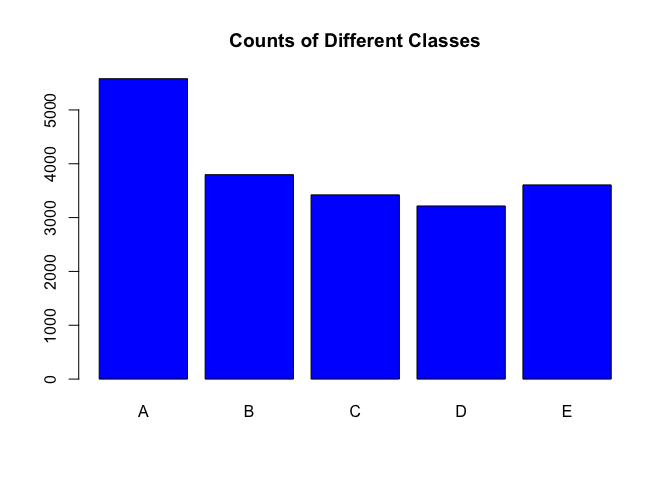

```r
plot(tidyTrainDf$classe, col = "blue", main="Counts of Different Classes")
```

### Testing three different models

We test three different methods of model building on a smaller (10%) subset of the training data to get an idea of which one should be used to create the model

```r
models <- c("svmLinear","rpart","rf")

for (m in 1:3) {
    fit <- train(classe ~ ., data=modeltest, method=models[m])
    mPrediction <- predict(fit, newdata=tidyTrainDf)
    print(paste("Percent correct predictions for method ", models[m], ":  ",
                round(100*sum(mPrediction==tidyTrainDf$classe)/nrow(tidyTrainDf)), " %", sep=""))
}
```

```
## [1] "Percent correct predictions for method svmLinear:  75 %"
## [1] "Percent correct predictions for method rpart:  37 %"
## [1] "Percent correct predictions for method rf:  95 %"
```

### The winner is the Random Forest (rf) method. We use that method to train using the entire training data set.

```r
modelFit <- train(classe ~ ., data=training, method="rf")
modelFit
# saveRDS(modelFit, "modelFit.RDS")
# modelFit = readRDS("modelFit.RDS")
```

[output not shown]

### Testing the in sample error on the training data

```r
trainingPrediction <- predict(modelFit, newdata=training)
confusionMatrix(trainingPrediction,training$classe)
```

```
## Confusion Matrix and Statistics
##
##           Reference
## Prediction    A    B    C    D    E
##          A 4185    0    0    0    0
##          B    0 2848    0    0    0
##          C    0    0 2567    0    0
##          D    0    0    0 2412    0
##          E    0    0    0    0 2706
##
## Overall Statistics
##
##                Accuracy : 1
##                  95% CI : (1, 1)
##     No Information Rate : 0.284
##     P-Value [Acc > NIR] : <2e-16
##
##                   Kappa : 1
##  Mcnemar's Test P-Value : NA
##
## Statistics by Class:
##
##                      Class: A Class: B Class: C Class: D Class: E
## Sensitivity             1.000    1.000    1.000    1.000    1.000
## Specificity             1.000    1.000    1.000    1.000    1.000
## Pos Pred Value          1.000    1.000    1.000    1.000    1.000
## Neg Pred Value          1.000    1.000    1.000    1.000    1.000
## Prevalence              0.284    0.194    0.174    0.164    0.184
## Detection Rate          0.284    0.194    0.174    0.164    0.184
## Detection Prevalence    0.284    0.194    0.174    0.164    0.184
## Balanced Accuracy       1.000    1.000    1.000    1.000    1.000
```

### Testing the out of sample error on the testing data

```r
testingPrediction <- predict(modelFit, newdata=testing)
confusionMatrix(testingPrediction, testing$classe)
```

```
## Confusion Matrix and Statistics
##
##           Reference
## Prediction    A    B    C    D    E
##          A 1392    5    0    0    0
##          B    2  941    7    0    1
##          C    0    3  845    8    0
##          D    0    0    3  795    4
##          E    1    0    0    1  896
##
## Overall Statistics
##
##                Accuracy : 0.993
##                  95% CI : (0.99, 0.995)
##     No Information Rate : 0.284
##     P-Value [Acc > NIR] : <2e-16
##
##                   Kappa : 0.991
##  Mcnemar's Test P-Value : NA
##
## Statistics by Class:
##
##                      Class: A Class: B Class: C Class: D Class: E
## Sensitivity             0.998    0.992    0.988    0.989    0.994
## Specificity             0.999    0.997    0.997    0.998    1.000
## Pos Pred Value          0.996    0.989    0.987    0.991    0.998
## Neg Pred Value          0.999    0.998    0.998    0.998    0.999
## Prevalence              0.284    0.194    0.174    0.164    0.184
## Detection Rate          0.284    0.192    0.172    0.162    0.183
## Detection Prevalence    0.285    0.194    0.175    0.164    0.183
## Balanced Accuracy       0.998    0.995    0.993    0.994    0.997
```

## Results

### Running the Model on the Submission Data

In this section, the machine learning algorithm built above is applied to the 20 test cases.

Tidy up the test data so that the dimensions match the training data

```r
finalDf <- testDf[ , which (naColumns==0)]
finalDf <- finalDf[, -c(1:7)]
```

Use the model to predict the answers for the project

```r
answer <- predict(modelFit, finalDf)
answer <- as.character(answer)
answer
```

```
##  [1] "B" "A" "B" "A" "A" "E" "D" "B" "A" "A" "B" "C" "B" "A" "E" "E" "A"
## [18] "B" "B" "B"
```

Write the answers to files for project submission

```r
pml_write_files = function(x) {
    n = length(x)
    for (i in 1:n) {
        filename = paste0("problem_id_", i, ".txt")
        write.table(as.character(x[i]), file = filename, quote = FALSE, row.names = FALSE,
            col.names = FALSE)
    }
}

pml_write_files(answer)
```